# Working throught various code

Group 10

2024-03-07

```r
library(tidyverse)
library(janitor)
library(naniar)
library(tidyr)
```

```r
spotify2023 <- read_csv("top_50_2023.csv") %>% clean_names()
split_spotify2023 <- spotify2023 %>%
  separate(genres, into = c("genre1", "genre2", "genre3", "genre4", "genre5", "genre6"), sep=",") %>%
  pivot_longer(cols = starts_with("genre"),
               names_to = "type",
               values_to = "class") %>%
  filter(class != "NA") %>%
  select(-type)
```

## Re-use select to pull out the punctuation

```r
split_spotify2023 <- split_spotify2023 %>%
  separate(class, into = c("punctuation", "class2"), sep = "'") %>%
  select(-punctuation)
```

## pivot_wider

```r
split_spotify2023 <- split_spotify2023 %>%
    pivot_wider(
        names_from = class2,
        values_from = class2,
        values_fn = length) %>%
  mutate(across(everything(), ~replace(.x, is.na(.x), 0)))
```

## Seperate the album release data into year, month, and day

```r
spotify <- split_spotify2023 %>%
  separate(album_release_date, into = c("year", "month", "day"), sep = "-") %>%
  clean_names()
```

```r
names(spotify)
```

```
##  [1] "artist_name"               "track_name"
##  [3] "is_explicit"               "year"
##  [5] "month"                     "day"
##  [7] "danceability"              "valence"
##  [9] "energy"                    "loudness"
## [11] "acousticness"              "instrumentalness"
## [13] "liveness"                  "speechiness"
## [15] "key"                       "tempo"
## [17] "mode"                      "duration_ms"
## [19] "time_signature"            "popularity"
## [21] "pop"                       "r_b"
## [23] "rap"                       "k_pop"
## [25] "corrido"                   "corridos_tumbados"
## [27] "sad_sierreno"              "sierreno"
## [29] "afrobeats"                 "nigerian_pop"
```

[output cut: 20 more lines]

## Count the total number of song in each column from pop to musica_chihuahuense and fill with springgreen3 and outline in black.

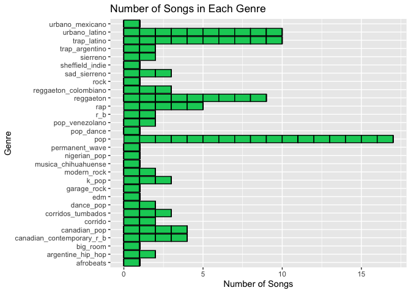

```r
spotify %>%
  select(pop:musica_chihuahuense) %>%
  gather(key = "genre", value = "count") %>%
  ggplot(aes(x = genre, y = count)) +
  geom_bar(stat = "identity", fill = "springgreen3", color="black") +
  labs(title = "Number of Songs in Each Genre",
       x = "Genre",
       y = "Number of Songs")+
  coord_flip()
```

## Pull all the pop songs and make a scatterplot graph with the dancibility and energy. Make sure to add color

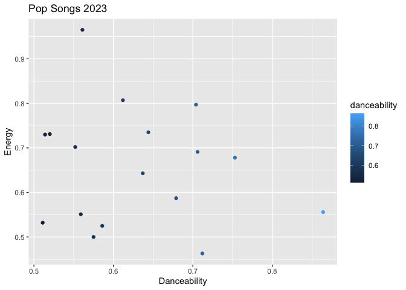

```r
spotify %>%
  filter(pop > 0) %>%
  ggplot(aes(x = danceability, y = energy, color = danceability)) +
  geom_point() +
  labs(title = "Pop Songs 2023",
       x = "Danceability",
       y = "Energy")
```

## Make a bar plot for all the songs released

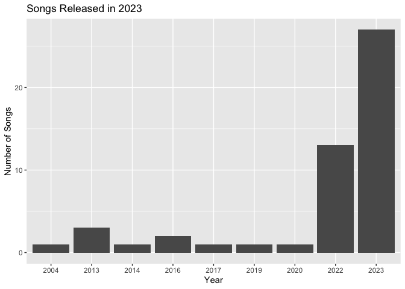

```r
spotify %>%
  ggplot(aes(x = year)) +
  geom_bar() +
  labs(title = "Songs Released in 2023",
       x = "Year",
       y = "Number of Songs")
```

## How many songs are in pop through rock? Make a graph

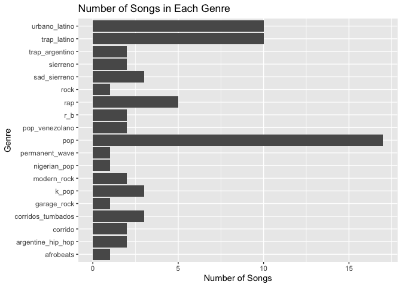

```r
spotify %>%
  select(pop:rock) %>%
  gather(key = "genre", value = "count") %>%
  ggplot(aes(x = genre, y = count)) +
  geom_bar(stat = "identity") +
  labs(title = "Number of Songs in Each Genre",
       x = "Genre",
       y = "Number of Songs")+
  coord_flip()
```

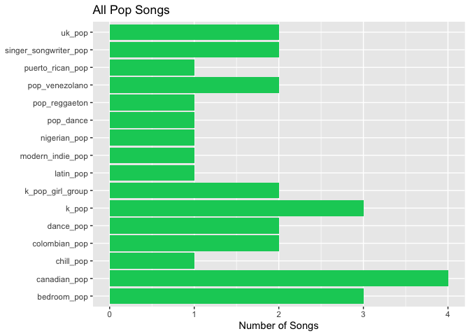

```r
spotify %>%
  select(contains("pop")) %>%
  select(-popularity) %>%
  gather(key = "pop", value = "count") %>%
  ggplot(aes(x = pop, y = count)) +
  geom_bar(stat = "identity", fill = "springgreen3") +
  labs(title = "All Pop Songs",
       x = NULL,
       y = "Number of Songs")+
  coord_flip()
```

## make a shiny app for all the graphs used so far. Make sure to include the headers and sidebar

```r
library(shiny)
library(shinydashboard)
```

```r
ui <- dashboardPage(
  dashboardHeader(title = "Spotify 2023"),
  dashboardSidebar(
    sidebarMenu(
      menuItem("Scatterplot", tabName = "scatter"),
      menuItem("Barplot", tabName = "bar"),
      menuItem("Genre Barplot", tabName = "genre"),
      menuItem("Pop Songs", tabName = "pop")
    )
  ),
  dashboardBody(
    tabItems(
      tabItem(tabName = "scatter",
              fluidRow(
                box(plotOutput("scatterplot", height = 250))
              )
      ),
      tabItem(tabName = "bar",
              fluidRow(
                box(plotOutput("barplot", height = 250))
              )
      ),
      tabItem(tabName = "genre",
              fluidRow(
                box(plotOutput("genrebarplot", height = 250))
              )
      ),
      tabItem(tabName = "pop",
              fluidRow(
                box(plotOutput("popbarplot", height = 250))
              )
      )
    )
  )
)

server <- function(input, output) {
  output$scatterplot <- renderPlot({
    spotify %>%
      filter(pop > 0) %>%
      ggplot(aes(x = danceability, y = energy, color = danceability)) +
      geom_point() +
      labs(title = "Pop Songs 2023",
           x = "Danceability",
           y = "Energy")
  })

  output$barplot <- renderPlot({
    spotify %>%
      ggplot(aes(x = year)) +
      geom_bar() +
      labs(title = "Songs Released in 2023",
           x = "Year",
           y = "Number of Songs")
  })

  output$genrebarplot <- renderPlot({
    spotify %>%
      select(pop:rock) %>%
      gather(key = "genre", value = "count") %>%
      ggplot(aes(x = genre, y = count)) +
      geom_bar(stat = "identity") +
      labs(title = "Number of Songs in Each Genre",
           x = "Genre",
           y = "Number of Songs")+
      coord_flip()
  })

  output$popbarplot <- renderPlot({
    spotify %>%
      select(contains("pop")) %>%
      select(-popularity) %>%
      gather(key = "pop", value = "count") %>%
      ggplot(aes(x = pop, y = count)) +
      geom_bar(stat = "identity") +
      labs(title = "All Pop Songs",
           x = NULL,
           y = "Number of Songs")+
      coord_flip()
  })
}

shinyApp(ui, server)
```

Shiny applications not supported in static R Markdown documents

## what is the most commonly occuring artist

```r
spotify %>%
  count(artist_name) %>%
  arrange(desc(n))
```

```
## # A tibble: 41 × 2
##    artist_name        n
##    <chr>          <int>
##  1 The Weeknd         4
##  2 Taylor Swift       3
##  3 Bad Bunny          2
##  4 Bizarrap           2
##  5 SZA                2
##  6 d4vd               2
##  7 Arctic Monkeys     1
##  8 David Guetta       1
##  9 David Kushner      1
## 10 Doja Cat           1
## # ℹ 31 more rows
```

## make a denisty graph on the duration of all songs and convert milliseconds to minutes. color the graph in springgreen3. chnage the bins size to 10

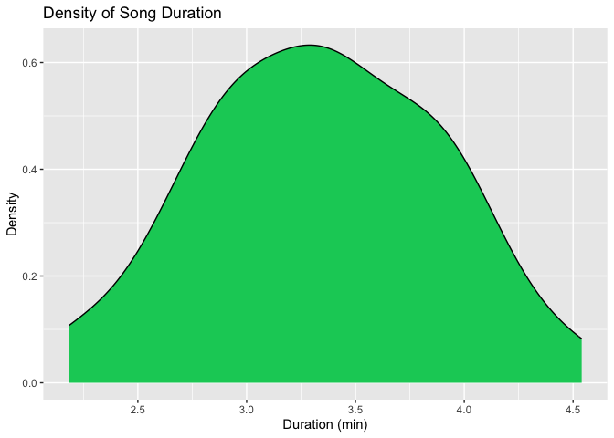

```r
spotify %>%
  mutate(duration_ms = duration_ms/60000) %>%
  ggplot(aes(x = duration_ms)) +
  geom_density(fill = "springgreen3") +
  labs(title = "Density of Song Duration",
       x = "Duration (min)",
       y = "Density")
```

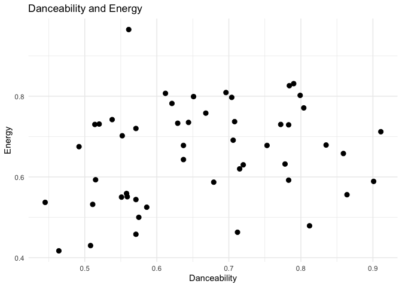

```r
spotify %>%
  ggplot(aes(x = danceability, y = energy)) +
  geom_point(size = 2.5) +
  labs(title = "Danceability and Energy",
       x = "Danceability",
       y = "Energy")+
  theme_minimal()
```

## what are all the k_pop and k_pop_girl_group songs

```r
spotify %>%
  filter(k_pop > 0 | k_pop_girl_group >0) %>%
  select(artist_name, track_name)
```

```
## # A tibble: 4 × 2
##   artist_name track_name
##   <chr>       <chr>
## 1 Jung Kook   Seven (feat. Latto) (Explicit Ver.)
## 2 FIFTY FIFTY Cupid - Twin Ver.
## 3 Jimin       Like Crazy
## 4 NewJeans    OMG
```

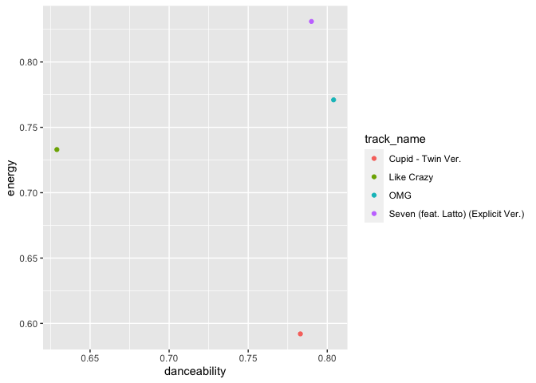

```r
spotify %>%
  filter(k_pop > 0 | k_pop_girl_group >0) %>%
  ggplot(aes(x = danceability, y = energy, color = track_name)) +
  geom_point()
```

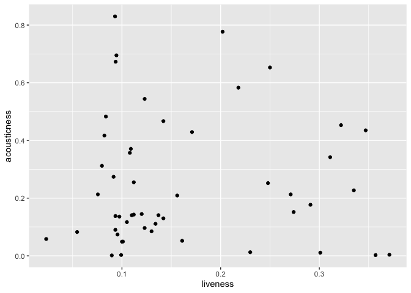

```r
spotify %>%
  ggplot(aes(x = liveness, y = acousticness)) +
  geom_point()
```

## Make a graph of the key versus valence. Split valence equally into 5 groups

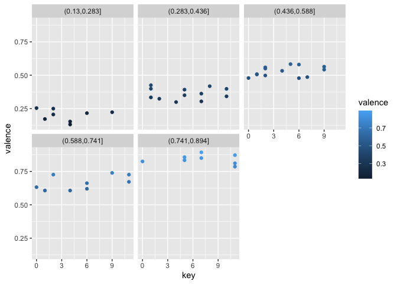

```r
spotify %>%
  ggplot(aes(x = key, y = valence, color = valence)) +
  geom_point() +
  facet_wrap(~cut(valence, 5))
```

## mutate is_explicit into 2 categories. make side by side boxplots of these categories and the loudness

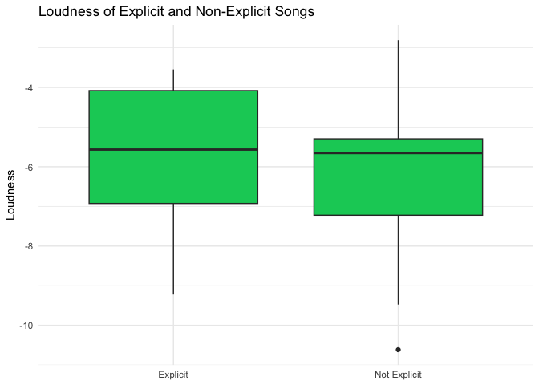

```r
spotify %>%
  mutate(is_explicit = ifelse(is_explicit == 1, "Explicit", "Not Explicit")) %>%
  ggplot(aes(x = is_explicit, y = loudness, fill = is_explicit)) +
  geom_boxplot(fill="springgreen3") +
  labs(title = "Loudness of Explicit and Non-Explicit Songs",
       x = NULL,
       y = "Loudness")+
  theme_minimal()
```

## Make a graph of the dancability and tempo

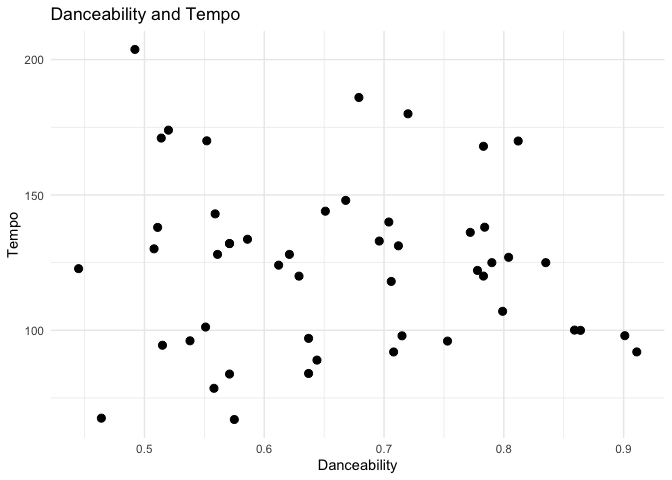

```r
spotify %>%
  ggplot(aes(x = danceability, y = tempo)) +
  geom_point(size=2.5) +
  labs(title = "Danceability and Tempo",
       x = "Danceability",
       y = "Tempo")+
  theme_minimal()
```

## Make a graph of the energy and tempo

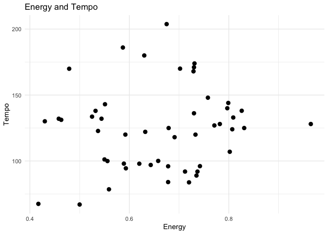

```r
spotify %>%
  ggplot(aes(x = energy, y = tempo)) +
  geom_point(size=2.5) +
  labs(title = "Energy and Tempo",
       x = "Energy",
       y = "Tempo")+
  theme_minimal()
```

## Make a graph of the dancability and valance. Add a regression line

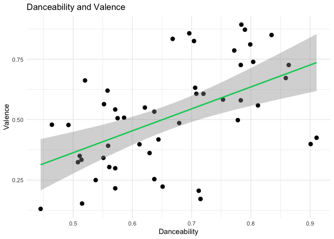

```r
spotify %>%
  ggplot(aes(x = danceability, y = valence)) +
  geom_point(size=2.5) +
  geom_smooth(method = "lm", color="springgreen3") +
  labs(title = "Danceability and Valence",
       x = "Danceability",
       y = "Valence")+
  theme_minimal()
```

Make a graph on energy and temp and increase the text size to 20 and make the text in the middle

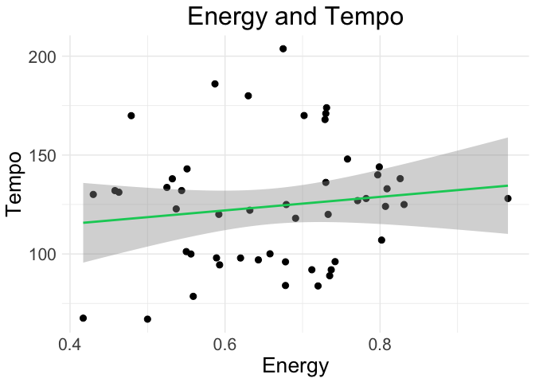

```r
spotify %>%
  ggplot(aes(x = energy, y = tempo)) +
  geom_point(size=2.5) +
  geom_smooth(method = "lm", color="springgreen3") +
  labs(title = "Energy and Tempo",
       x = "Energy",
       y = "Tempo")+
  theme_minimal()+
  theme(text = element_text(size = 20))+
  theme(plot.title = element_text(hjust = 0.5))
```

## Make a graph of the acousticts and liveiness

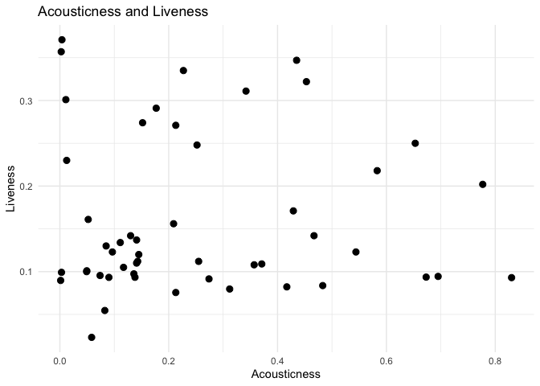

```r
spotify %>%
  ggplot(aes(x = acousticness, y = liveness)) +
  geom_point(size=2.5) +
  labs(title = "Acousticness and Liveness",
       x = "Acousticness",
       y = "Liveness")+
  theme_minimal()
```

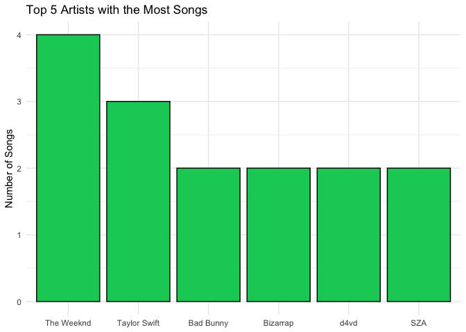

```r
spotify %>%
  count(artist_name) %>%
  top_n(5) %>%
  ggplot(aes(x = reorder(artist_name, -n), y = n)) +
  geom_bar(stat = "identity", fill = "springgreen3", color="black") +
  labs(title = "Top 5 Artists with the Most Songs",
       x = NULL,
       y = "Number of Songs")+
  theme_minimal()
```